# Krause/Niazi et al. DNA Data Analysis

Adnan M. Niazi & Maximillian Krause

5/13/2019

This document contains all the analyses done on ONT DNA data that was generated for the tailfindr paper. Knit this R markdown file after you have successfully run `drake::r_make()`.

Load the required libraries first:

```r
pacman::p_load(dplyr, magrittr, ggplot2, drake, knitr, ggpubr, here, tidyverse)
```

Now load the data:

```r
loadd(dna_kr_data)
```

Here is a description of columns of `dna_kr_data`:

```r
knitr::kable(col_names_df)
```

| Columns | Description |
| --- | --- |
| read_id | Read ID |
| tail_start_ff | tailfindr estimate of poly(A) start site based on flipflop basecalling |
| tail_end_ff | tailfindr estimate of poly(A) end site based on flipflop basecalling |
| samples_per_nt_ff | tailfindr estimate of read-specific translocation rate in units of samples per nucleotide based on flipflop basecalling |
| tail_length_ff | tailfindr estimate of poly(A) tail length based on flipflop basecalling |
| tail_start_st | tailfindr estimate of poly(A) start site from standard model basecalling |
| tail_end_st | tailfindr estimate of poly(A) end site from standard model basecalling |
| samples_per_nt_st | tailfindr estimate of read-specific translocation rate in units of samples per nucleotide from dstandard model basecalling |
| tail_length_st | tailfindr estimate of poly(A) tail length from standard model basecalling |
| read_type | Whether the read is poly(A) or poly(T) read |
| barcode | Expected poly(A)/(T) tail length from spikeins |
| replicate | Replicate No |
| file_path | Full file path (relevant only for use within Valen lab) |
| transcript_alignment_start_st | Location of tail end by eGFP sequence alignment (standard model basecalling) |
| transcript_alignment_start_ff | Location of tail end by eGFP sequence alignment (flipflop model basecalling |

### Data summary

```r
# define the function for computing standard error
std_err <- function(x) sd(x, na.rm = TRUE)/sqrt(length(x))

# summarize the data and display a table
summary_data <- dna_kr_data %>% group_by(barcode, read_type) %>%
  summarise(read_count = n(),
            mean = mean(tail_length_st, na.rm = TRUE),
            median = median(tail_length_st, na.rm = TRUE),
            std_dev = sd(tail_length_st, na.rm = TRUE),
            std_err = std_err(tail_length_st))
summary_data %<>% mutate(cof_var = std_dev/mean)
kable(summary_data)
```

| barcode | read_type | read_count | mean | median | std_dev | std_err | cof_var |
| --- | --- | --- | --- | --- | --- | --- | --- |
| 10 | polyA | 3850 | 12.83470 | 9.27000 | 15.25476 | 0.2458528 | 1.1885568 |
| 10 | polyT | 11072 | 14.27321 | 10.95000 | 17.32021 | 0.1646039 | 1.2134766 |
| 30 | polyA | 12858 | 28.42722 | 27.39000 | 10.49006 | 0.0925106 | 0.3690147 |
| 30 | polyT | 17087 | 29.92357 | 28.60000 | 14.00484 | 0.1071384 | 0.4680201 |
| 40 | polyA | 6826 | 36.56306 | 36.57500 | 12.83846 | 0.1553925 | 0.3511321 |
| 40 | polyT | 13811 | 37.35623 | 38.01000 | 16.03852 | 0.1364746 | 0.4293400 |
| 60 | polyA | 8065 | 53.56193 | 55.47000 | 16.73813 | 0.1863824 | 0.3125005 |
| 60 | polyT | 10073 | 51.64352 | 57.56465 | 24.32128 | 0.2423299 | 0.4709454 |
| 100 | polyA | 2959 | 89.93859 | 92.72000 | 22.34206 | 0.4107246 | 0.2484146 |
| 100 | polyT | 3167 | 89.88751 | 99.29374 | 34.44611 | 0.6120912 | 0.3832135 |
| 150 | polyA | 1693 | 121.62783 | 132.27000 | 39.53762 | 0.9609086 | 0.3250705 |
| 150 | polyT | 2535 | 117.56694 | 128.08000 | 49.71003 | 0.9873135 | 0.4228232 |

### tailfindr tail length estimation across replicates

To find out how robust the tail length estimated by tailfindr is across technical replicates:

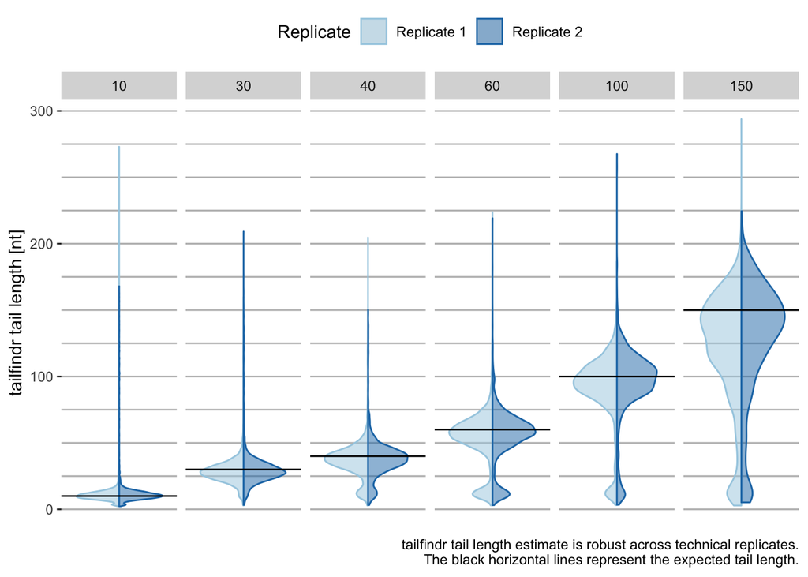

```r
p <- ggplot(dna_kr_data, aes(x = barcode, y = tail_length_st,
                             color = replicate, fill = replicate)) +
  geom_two_sided_flat_violin(position = position_nudge(x = 0, y = 0), alpha = .5) +
  facet_grid(~barcode, scales = 'free') +
  geom_hline(aes(yintercept = as.numeric(as.character(barcode))))
```

### tailfindr tail length comparison between poly(A) and poly(T) read types

To address whether estimated tail lengths of poly(A) and poly(T) reads are comparable:

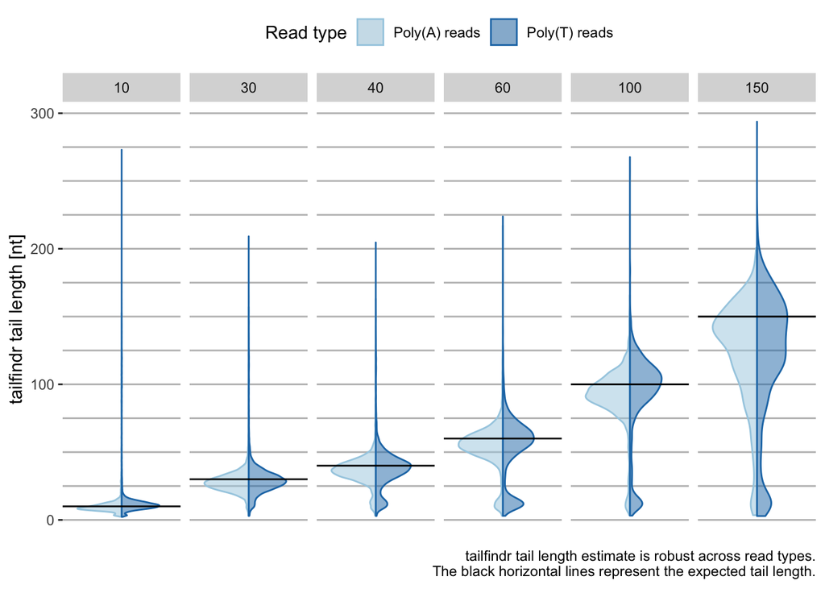

```r
p <- ggplot(dna_kr_data, aes(x = barcode, y = tail_length_st,
                             color = read_type, fill = read_type)) +
  geom_two_sided_flat_violin(position = position_nudge(x = 0, y = 0), alpha = .5) +
  facet_grid(~barcode, scales = 'free') +
  geom_hline(aes(yintercept = as.numeric(as.character(barcode))))
```

### tailfindr tail length comparison between flipflop and standard basecalling

To test whether basecalling strategy (standard model vs flip-flop model basecalling) has an influence on poly(A) length estimation:

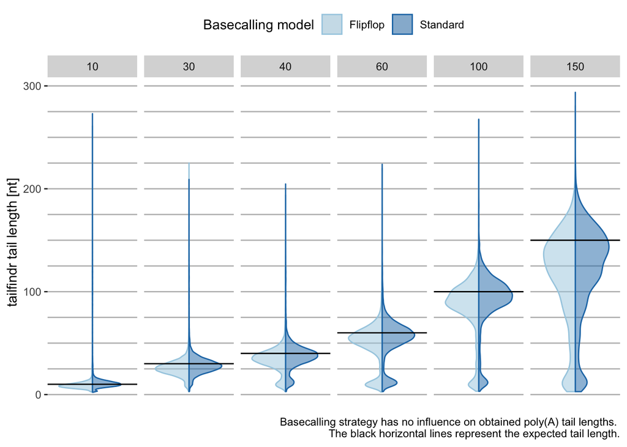

```r
# make data first
long_dna_data <- dna_kr_data %>% select(barcode, tail_length_ff, tail_length_st) %>%
  gather(key = 'basecaller', value = 'tail_length', tail_length_ff, tail_length_st)

p <- ggplot(long_dna_data, aes(x = barcode, y = tail_length,
                             color = basecaller, fill = basecaller)) +
  geom_two_sided_flat_violin(position = position_nudge(x = 0, y = 0), alpha = .5) +
  facet_grid(~barcode, scales = 'free') +
  geom_hline(aes(yintercept = as.numeric(as.character(barcode))))
```

### tailfindr tail end estimate vs. tail end obtained by alignment of eGFP

First a new column `transcript_end_tf`is produced in our dataset. This column holds the tailfindr boundary location which is adjacent to transcript:

```r
dna_kr_data %<>%
  mutate(transcript_end_tf = ifelse(read_type == 'polyA',
                                    tail_start_ff, tail_end_ff))
```

To visualize whether the coordinates of the tail end estimated by tailfindr match up with those obtained from the alignment with eGFP sequence:

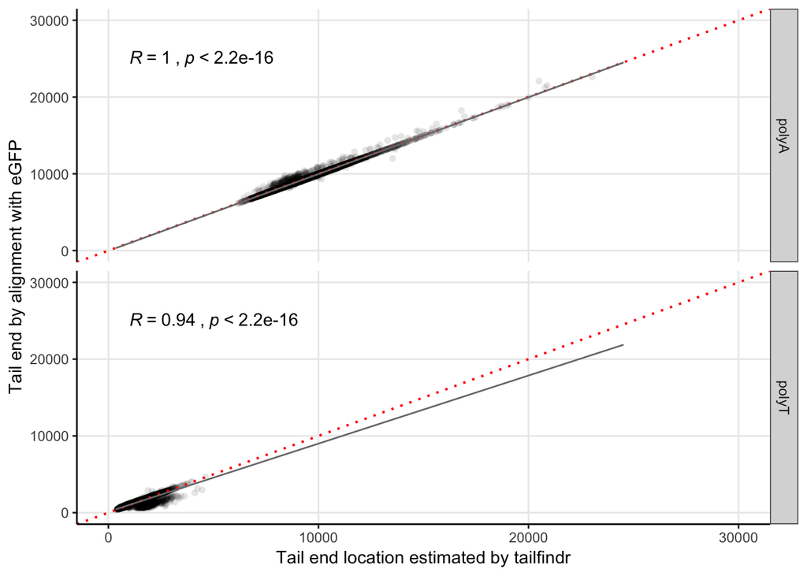

```r
p <- ggplot(dna_kr_data, aes(x = transcript_end_tf, y = transcript_alignment_start_ff)) +
    geom_point(shape = 21, colour = 'black', fill = 'black',
               size = 2, stroke=0, alpha = 0.1) +
    geom_abline(intercept = 0, slope = 1, color="red",
                linetype = 'dotted', size = 0.7) +
    geom_smooth(method = 'lm',formula = y~x, color="#797979",
                fullrange = TRUE, se = FALSE, size = 0.5) +
    stat_cor(method = "pearson", label.x = 1000, label.y = 25000) +
    coord_cartesian(xlim = c(0, 30000), ylim = c(0, 30000)) +
  facet_grid(read_type~.)
```

To better visulize the difference, the same information is plotted as histogram:

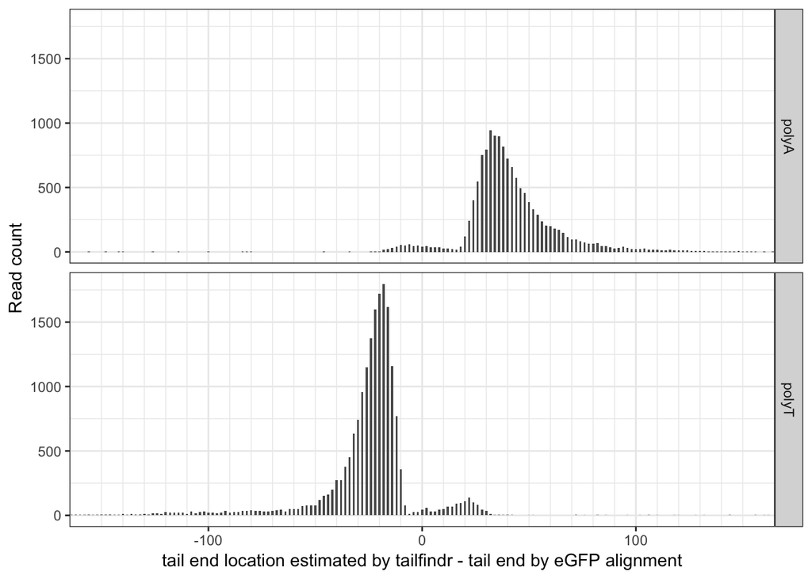

```r
hist_data <- mutate(dna_kr_data, diff = transcript_end_tf - transcript_alignment_start_ff)
p <- ggplot(hist_data, aes(x = diff)) +
  geom_histogram(binwidth = 1) +
  facet_grid(read_type~.)
```

### Analysis of spurious peak around 12 in the density plots

First, classify the reads into erroneous and non-erroneous read

```r
# Erroneous reads have tail length between 9 and 15
spurious_peak_data <- dna_kr_data %>%
  filter(barcode == 60 | barcode == 100 | barcode == 150) %>%
  mutate(read_classification =
           if_else(tail_length_st >= 9 & tail_length_st <= 15,
                   'erroneous',
                   'non-erroneous'))
```

#### a. Read rate density from erroneous vs non-erroneous reads

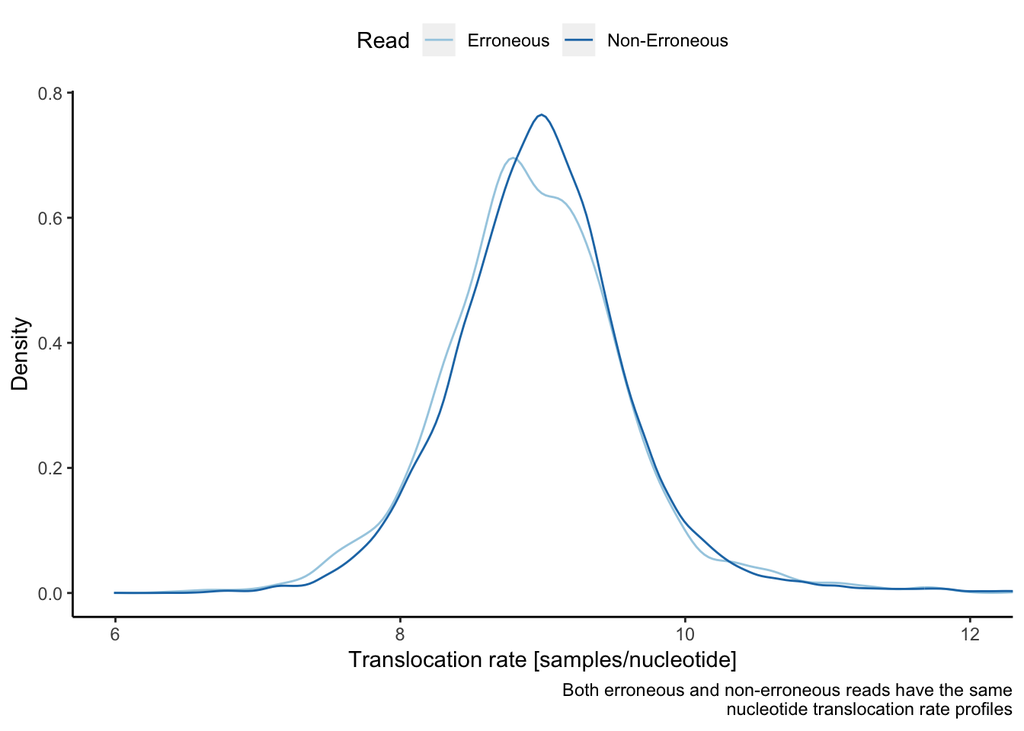

```r
p <- ggplot(spurious_peak_data, aes(x = samples_per_nt_st,
                                    color = read_classification)) +
  geom_line(stat = 'density')
```

#### b. Raw tail length vs. normalizer for erroneous and non-erroneous reads

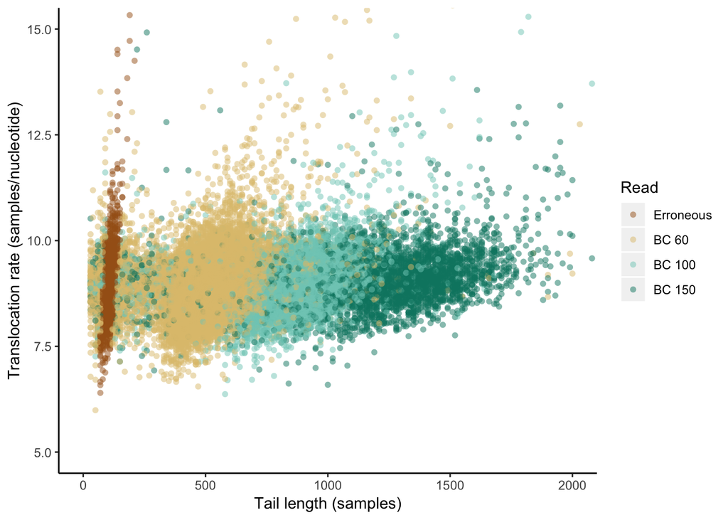

```r
spurious_peak_data %<>%
  mutate(tail_length_in_samples_st = tail_end_st - tail_start_st) %>%
  mutate(barcode = as.character(barcode)) %>%
  mutate(barcode = ifelse(read_classification == 'erroneous', 'erroneous', barcode)) %>%
  mutate(barcode = fct_relevel(barcode, "erroneous", "60", "100", "150"))

p <- ggplot(spurious_peak_data, aes(x = tail_length_in_samples_st,
                                    y = samples_per_nt_st,
                                    color = barcode)) +
  geom_point(alpha = 0.5, stroke = 0, size = 2)
```

#### c. eGFP alignment end vs tailfindr end on erroneoush vs non-erroneous reads

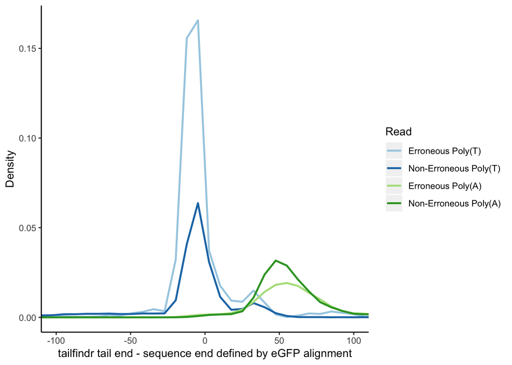

```r
spurious_peak_data %<>%
  mutate(transcript_end_st = ifelse(read_type == 'polyA',
                                    tail_start_st,
                                    tail_end_st)) %>%
  mutate(diff = transcript_end_st - transcript_alignment_start_st) %>%
  mutate(
    read_classification =
      case_when(
        read_type == 'polyT' &
          read_classification == 'erroneous' ~ "erroneous_polyt",
        read_type == 'polyT' &
          read_classification == 'non-erroneous' ~ "non-erroneous_polyt",
        read_type == 'polyA' &
          read_classification == 'erroneous' ~ "erroneous_polya",
        read_type == 'polyA' &
          read_classification == 'non-erroneous' ~ "non-erroneous_polya"
      )
  ) %>%
  mutate(read_classification = fct_relevel(read_classification,
                                           "erroneous_polyt",
                                           "non-erroneous_polyt",
                                           "erroneous_polya",
                                           "non-erroneous_polya"))

p <- ggplot(spurious_peak_data, aes(x = diff,
                                    color = read_classification)) +
  geom_line(stat = 'density', size = 0.9)
```

### Justification for DNA thresholds

```r
model_180mv <- here('extdata', 'r9.4_180mv_450bps_6mer_template_median68pA.model')
df_180mv <- read.csv(model_180mv, header = TRUE,
                     stringsAsFactors = FALSE, sep = '\t')

df_180mv <- as.tibble(df_180mv)

# sample 100 numbers from a Gaussian distribution for each kmer mu and sd
set.seed(5)
df_180mv %<>% select(kmer, level_mean, level_stdv) %>%
  rowwise() %>%
  mutate(sampled_numbers = list(rnorm(n=1000, level_mean, level_stdv)))

sampled_numbers <- purrr::flatten(df_180mv$sampled_numbers)
sampled_numbers <- unlist(sampled_numbers, recursive = FALSE)

# Calculate mean and sd of AAAAA state, and all the kmers combined
mean_AAAAAA <- mean(unlist(df_180mv$sampled_numbers[1]))
sd_AAAAAA <- sd(unlist(df_180mv$sampled_numbers[1]))
mean_TTTTTT <- mean(unlist(df_180mv$sampled_numbers[4096]))
sd_TTTTTT <- sd(unlist(df_180mv$sampled_numbers[4096]))
mean_all_kmers <- mean(sampled_numbers)
sd_all_kmers <- sd(sampled_numbers)

minimum_expected_nomrmalized_AAAAAA_level  <-
  ((mean_AAAAAA - 2 * sd_AAAAAA) - mean_all_kmers) / sd_all_kmers

cat(paste0("Minimum expected nomrmalized AAAAAA level: ",
           abs(minimum_expected_nomrmalized_AAAAAA_level), '\n'))
```

```
## Minimum expected nomrmalized AAAAAA level: 0.518144121551562
```

```r
minimum_expected_nomrmalized_TTTTTT_level  <-
  ((mean_TTTTTT - 2 * sd_TTTTTT) - mean_all_kmers) / sd_all_kmers

cat(paste0("Minimum expected nomrmalized TTTTTT level: ",
           abs(minimum_expected_nomrmalized_TTTTTT_level), '\n'))
```

```
## Minimum expected nomrmalized TTTTTT level: 0.20178577950747
```